# Priority and Niceness of Linux Processes

## Disclaimer

Some hints to assign different levels of priority to different jobs running on the same linux machine. The facts shown here are mostly based on https://askubuntu.com/questions/656771/process-niceness-vs-priority.

## Background

There are different sources about process priorities on a linux system and their relation to niceness and the program `nice`. Examples are

- https://en.wikipedia.org/wiki/Nice_(Unix)
- https://www.howtogeek.com/411979/how-to-set-process-priorities-with-the-nice-and-renice-commands-in-linux/
- https://www.thegeekdiary.com/unix-linux-how-to-change-the-niceness-priority-of-a-process/

In summary, the user can use the program `nice` to assign a niceness value (see Practical Example) when starting a process. One has to be careful when starting different processes in parallel from inside a script, because all the processes started from inside the master-script would be required to start with a given `nice` command. In such a scenario, perhaps the program `renice` is more suited. This lets you re-assign a niceness value to a certain script.

It is important to remember that when looking at a top-output lower values of priority (`PR`) and nice (`NI`) are associated with a higher priority. The following relation holds between `PR` and `NI`: $PR = 20 + NI$.

## Practical Example

```bash
./prog/runBayesCPi.sh work/gsRuns.txt.1
```

The above command starts a number of `GenSel` jobs. Using the `top` output, we can see that the `GenSel` jobs are running with some other jobs with all the same `NI` values.

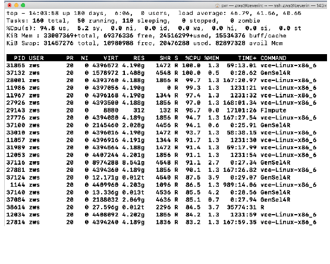

## Assign Different Priority

In case we want to assign a different `NI` value to all the `GenSel` jobs, we can do this with the following statement.

```bash
renice 19 -p $(pgrep GenSel4R)
```

This changes the top-output to the following

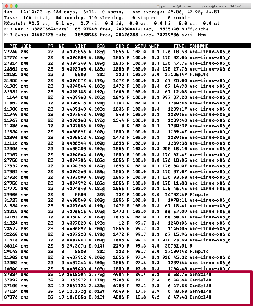